# Corona Virus: Answering Questions I have

### Cases across all countries

Next, let’s analyze the number of confirmed cases for all coutries. Again, I fit a simple model to capture the pattern. I fit a degree 3 polynomial to capture the pattern thus far, and extrapolate it for the next 15 days. Additionally, I add a weight that gives greater weights to later time points, the goal of this is to capture the possible effect of the significant worldwide social distancing efforts. Of course, this does not entirely capture the effect of the social distancing, especially what we will see in the coming days. But if nothing were done, this could be a very likely scenario. The scary thing with this fit is that the regression has an Adjusted R-squared of 0.9939, showing how good a fit this simple regression model is to the data.

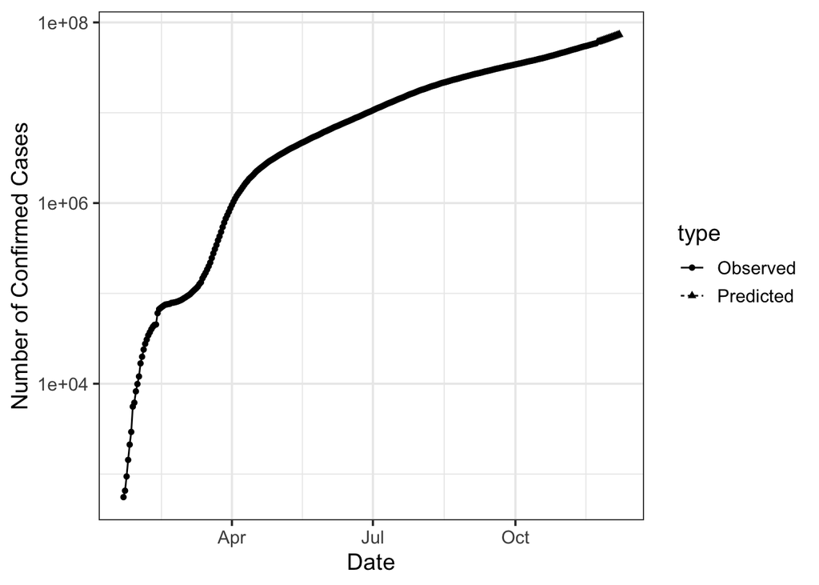

## Deaths

Let’s look at the daily counts deaths by country. Below are the counts in their natural scale.

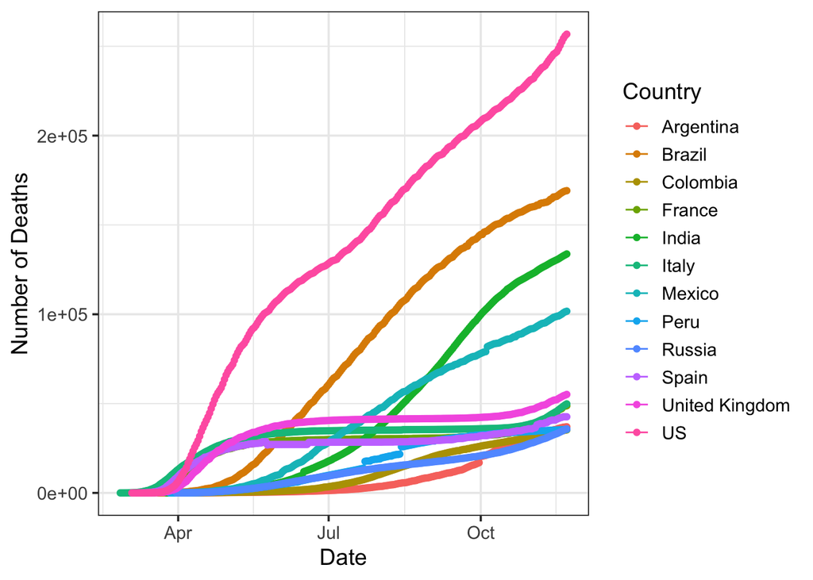

Below are the top countries by deaths as off today, 2020-11-23.

The top countries by Number of Deaths

| Country | total_deaths |
| --- | --- |
| US | 256782 |
| Brazil | 169183 |
| India | 133738 |
| Mexico | 101676 |
| United Kingdom | 55120 |
| Italy | 49823 |
| France | 48807 |
| Iran | 44802 |
| Spain | 42619 |
| Argentina | 37002 |
| Russia | 35838 |
| Peru | 35549 |
| Colombia | 35287 |
| South Africa | 20903 |
| Indonesia | 15884 |

Let’s look at the same plot on the logarithmic scale.

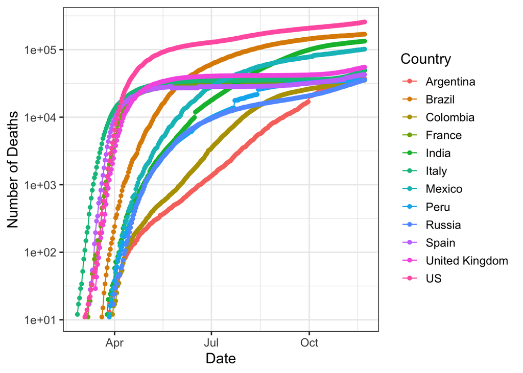

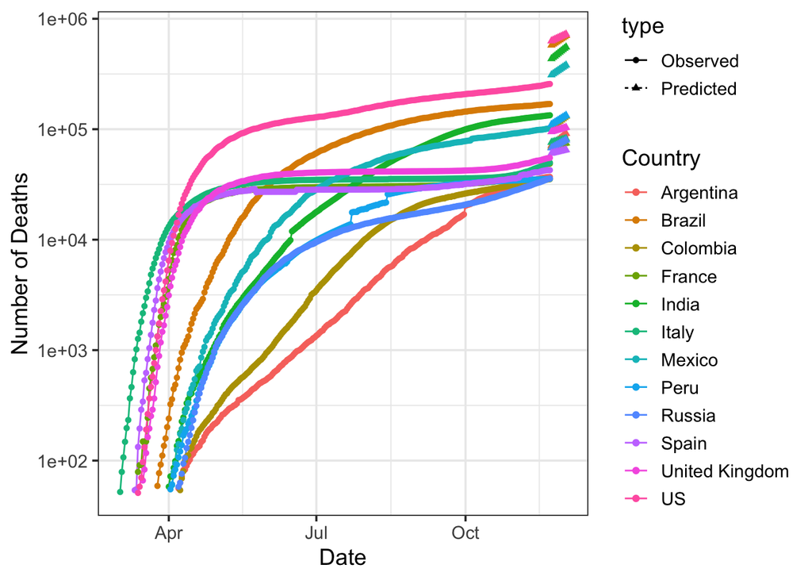

### Deaths across all countries

Next, let’s analyze the deaths for all coutries. Again, I fit a simple model to capture the pattern. I fit a degree 3 polynomial to capture the pattern thus far, and extrapolate it for the next 15 days. Of course, this does not capture the effect of the social distancing efforts that are currently on-going all over the world. But if nothing were done, this could be a very likely scenario. The scary thing with this fit is that the regression has an Adjusted R-squared of 0.9986, showing how good a fit this simple regression model is to the data.

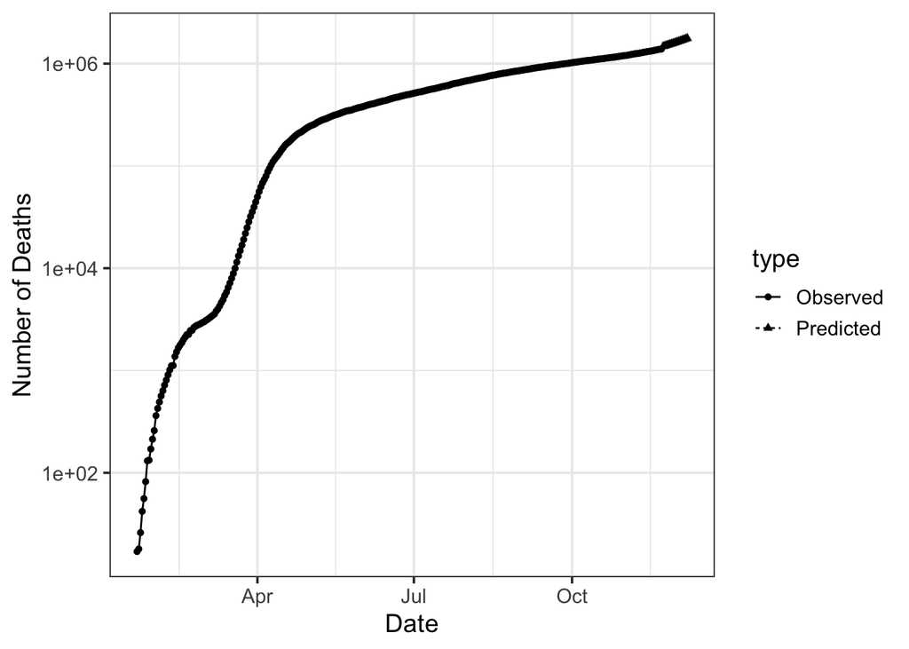

## Are we over the peak?

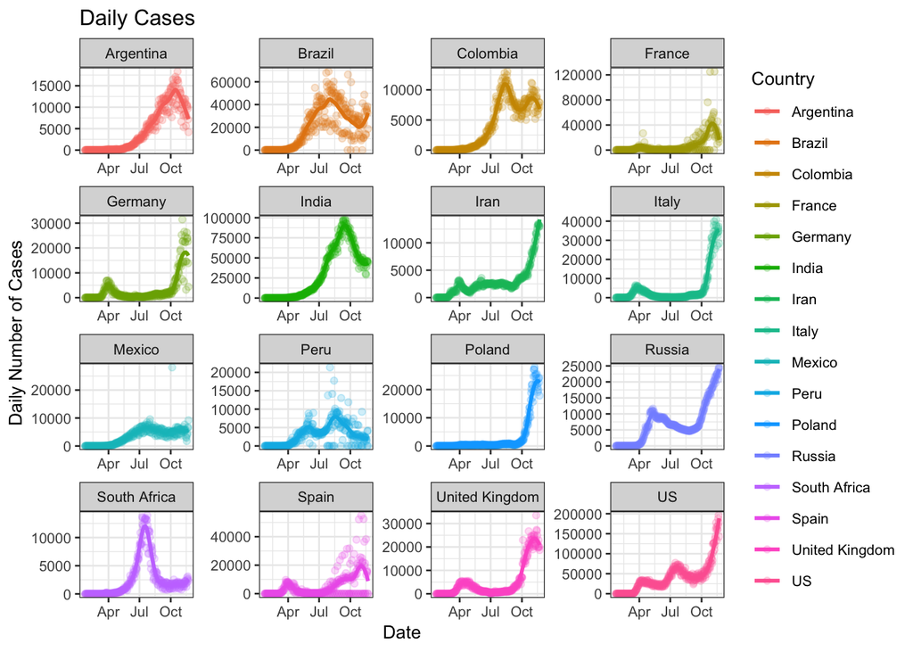

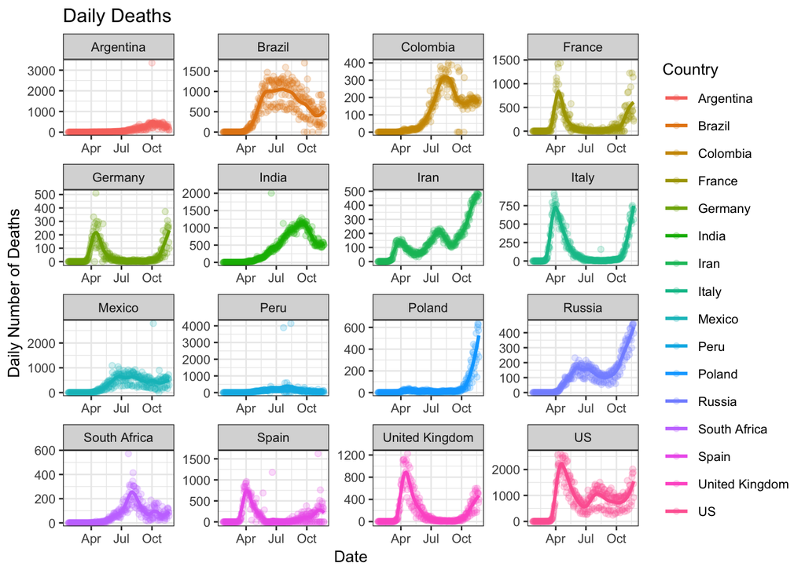

## Mortality Rate

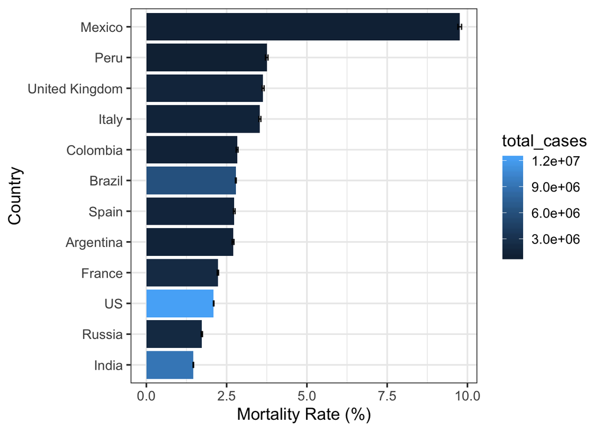

1. Force 1: The **denominator is low**, not all cases (especially the mild cases are not tested). If this is true, as testing rolls out extensively, we expect to see the mortality rate to fall.
2. Force 2: The **numerator is low**, many people who die will likely pass away weeks or months from case confirmation. This means that the mortality rate will grow as time passes.

Let’s look at a few cases below.

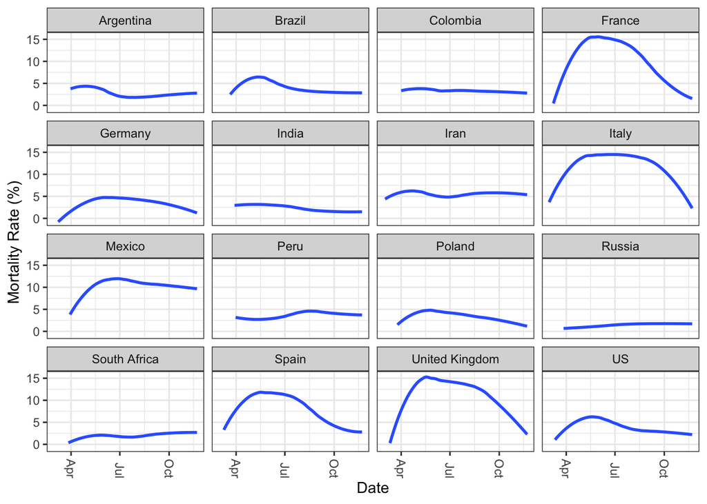